# How do we read plays into R?

pmd

The plays that we are working with are in a TEI-format. However, R does not have a standard method to read TEI, which is why we convert the TEI-files to a format more suitable for R. Here, we choose JSONL, although there are a number of formats to choose from. In JSONL, each line is in itself a valid piece of JSON, while the file as a whole is not. This means that each line can be read into R on its own.

To make the conversion to JSONL simple, we have written two short R functions: One that converts all TEI-files inside a folder, and one that reads all JSONL-files in the folder into R.

This notebook shows you how to use these functions.

Before we start, we need to load the necessary packages into R.

```
library(tidyverse)
library(ndjson)
library(here)
library(fs)
library(xslt)
```

The two functions for converting to and reading JSONL are defined in the file `src/p017-functions.R`, which we read into R in the following way:

```
source(here("src", "p017-functions.R"))
```

# Conversion of TEI-files from a folder

```
my_dir <-"test-data"
dir_ls(here(my_dir))
```

```
/Users/maxbookair/workspace/characters-dramaturgical-structures-2025/test-data/Abracadabra_mod.jsonl
/Users/maxbookair/workspace/characters-dramaturgical-structures-2025/test-data/Abracadabra_mod.page
/Users/maxbookair/workspace/characters-dramaturgical-structures-2025/test-data/Barselstuen_mod.jsonl
/Users/maxbookair/workspace/characters-dramaturgical-structures-2025/test-data/Barselstuen_mod.page
/Users/maxbookair/workspace/characters-dramaturgical-structures-2025/test-data/Bondedreng_mod.jsonl
/Users/maxbookair/workspace/characters-dramaturgical-structures-2025/test-data/Bondedreng_mod.page
/Users/maxbookair/workspace/characters-dramaturgical-structures-2025/test-data/Brudgom_mod.jsonl
/Users/maxbookair/workspace/characters-dramaturgical-structures-2025/test-data/Brudgom_mod.page
/Users/maxbookair/workspace/characters-dramaturgical-structures-2025/test-data/De_u-synlige_mod.jsonl
/Users/maxbookair/workspace/characters-dramaturgical-structures-2025/test-data/De_u-synlige_mod.page
/Users/maxbookair/workspace/characters-dramaturgical-structures-2025/test-data/Den_11_Junii_mod.jsonl
/Users/maxbookair/workspace/characters-dramaturgical-structures-2025/test-data/Den_11_Junii_mod.page
/Users/maxbookair/workspace/characters-dramaturgical-structures-2025/test-data/Den_Honnette_Ambition_mod.jsonl
/Users/maxbookair/workspace/characters-dramaturgical-structures-2025/test-data/Den_Honnette_Ambition_mod.page
/Users/maxbookair/workspace/characters-dramaturgical-structures-2025/test-data/Den_Stundesloese_mod.jsonl
/Users/maxbookair/workspace/characters-dramaturgical-structures-2025/test-data/Den_Stundesloese_mod.page
/Users/maxbookair/workspace/characters-dramaturgical-structures-2025/test-data/Den_Vaegelsindede_1723_mod.jsonl
/Users/maxbookair/workspace/characters-dramaturgical-structures-2025/test-data/Den_Vaegelsindede_1723_mod.page
/Users/maxbookair/workspace/characters-dramaturgical-structures-2025/test-data/Den_Vaegelsindede_1731_mod.jsonl
/Users/maxbookair/workspace/characters-dramaturgical-structures-2025/test-data/Den_Vaegelsindede_1731_mod.page
/Users/maxbookair/workspace/characters-dramaturgical-structures-2025/test-data/Det_Arabiske_Pulver_mod.jsonl
/Users/maxbookair/workspace/characters-dramaturgical-structures-2025/test-data/Det_Arabiske_Pulver_mod.page
/Users/maxbookair/workspace/characters-dramaturgical-structures-2025/test-data/Diderich_mod.jsonl
/Users/maxbookair/workspace/characters-dramaturgical-structures-2025/test-data/Diderich_mod.page
/Users/maxbookair/workspace/characters-dramaturgical-structures-2025/test-data/Erasmus_mod.jsonl
/Users/maxbookair/workspace/characters-dramaturgical-structures-2025/test-data/Erasmus_mod.page
/Users/maxbookair/workspace/characters-dramaturgical-structures-2025/test-data/GertWestphaler1723_mod.jsonl
/Users/maxbookair/workspace/characters-dramaturgical-structures-2025/test-data/GertWestphaler1723_mod.page
/Users/maxbookair/workspace/characters-dramaturgical-structures-2025/test-data/GertWestphaler1724_mod.jsonl
/Users/maxbookair/workspace/characters-dramaturgical-structures-2025/test-data/GertWestphaler1724_mod.page
/Users/maxbookair/workspace/characters-dramaturgical-structures-2025/test-data/Henrick_og_Pernille_mod.jsonl
/Users/maxbookair/workspace/characters-dramaturgical-structures-2025/test-data/Henrick_og_Pernille_mod.page
/Users/maxbookair/workspace/characters-dramaturgical-structures-2025/test-data/Hexerie_mod.jsonl
/Users/maxbookair/workspace/characters-dramaturgical-structures-2025/test-data/Hexerie_mod.page
/Users/maxbookair/workspace/characters-dramaturgical-structures-2025/test-data/Jacob_von_Tyboe_mod.jsonl
/Users/maxbookair/workspace/characters-dramaturgical-structures-2025/test-data/Jacob_von_Tyboe_mod.page
/Users/maxbookair/workspace/characters-dramaturgical-structures-2025/test-data/Jean_de_France_mod.jsonl
/Users/maxbookair/workspace/characters-dramaturgical-structures-2025/test-data/Jean_de_France_mod.page
/Users/maxbookair/workspace/characters-dramaturgical-structures-2025/test-data/Jeppe_mod.jsonl
/Users/maxbookair/workspace/characters-dramaturgical-structures-2025/test-data/Jeppe_mod.page
```

[output cut: 17 more lines]

```
/Users/maxbookair/workspace/characters-dramaturgical-structures-2025/test-data/Philosophus_mod.page
/Users/maxbookair/workspace/characters-dramaturgical-structures-2025/test-data/Plutus_mod.jsonl
/Users/maxbookair/workspace/characters-dramaturgical-structures-2025/test-data/Plutus_mod.page
/Users/maxbookair/workspace/characters-dramaturgical-structures-2025/test-data/Ranudo_mod.jsonl
/Users/maxbookair/workspace/characters-dramaturgical-structures-2025/test-data/Ranudo_mod.page
/Users/maxbookair/workspace/characters-dramaturgical-structures-2025/test-data/Republiqven_mod.jsonl
/Users/maxbookair/workspace/characters-dramaturgical-structures-2025/test-data/Republiqven_mod.page
/Users/maxbookair/workspace/characters-dramaturgical-structures-2025/test-data/Sganarel_mod.jsonl
/Users/maxbookair/workspace/characters-dramaturgical-structures-2025/test-data/Sganarel_mod.page
/Users/maxbookair/workspace/characters-dramaturgical-structures-2025/test-data/Skibbrud_mod.jsonl
/Users/maxbookair/workspace/characters-dramaturgical-structures-2025/test-data/Skibbrud_mod.page
/Users/maxbookair/workspace/characters-dramaturgical-structures-2025/test-data/Ulysses_mod.jsonl
/Users/maxbookair/workspace/characters-dramaturgical-structures-2025/test-data/Ulysses_mod.page
/Users/maxbookair/workspace/characters-dramaturgical-structures-2025/test-data/uden_hoved_og_hale_mod.jsonl
/Users/maxbookair/workspace/characters-dramaturgical-structures-2025/test-data/uden_hoved_og_hale_mod.page
```

```
convert_TEI_to_JSONL(here(my_dir))
```

```
dir_ls(here(my_dir))
```

```
/Users/maxbookair/workspace/characters-dramaturgical-structures-2025/test-data/Abracadabra_mod.jsonl
/Users/maxbookair/workspace/characters-dramaturgical-structures-2025/test-data/Abracadabra_mod.page
/Users/maxbookair/workspace/characters-dramaturgical-structures-2025/test-data/Barselstuen_mod.jsonl
/Users/maxbookair/workspace/characters-dramaturgical-structures-2025/test-data/Barselstuen_mod.page
/Users/maxbookair/workspace/characters-dramaturgical-structures-2025/test-data/Bondedreng_mod.jsonl
/Users/maxbookair/workspace/characters-dramaturgical-structures-2025/test-data/Bondedreng_mod.page
/Users/maxbookair/workspace/characters-dramaturgical-structures-2025/test-data/Brudgom_mod.jsonl
/Users/maxbookair/workspace/characters-dramaturgical-structures-2025/test-data/Brudgom_mod.page
/Users/maxbookair/workspace/characters-dramaturgical-structures-2025/test-data/De_u-synlige_mod.jsonl
/Users/maxbookair/workspace/characters-dramaturgical-structures-2025/test-data/De_u-synlige_mod.page
/Users/maxbookair/workspace/characters-dramaturgical-structures-2025/test-data/Den_11_Junii_mod.jsonl
/Users/maxbookair/workspace/characters-dramaturgical-structures-2025/test-data/Den_11_Junii_mod.page
/Users/maxbookair/workspace/characters-dramaturgical-structures-2025/test-data/Den_Honnette_Ambition_mod.jsonl
/Users/maxbookair/workspace/characters-dramaturgical-structures-2025/test-data/Den_Honnette_Ambition_mod.page
/Users/maxbookair/workspace/characters-dramaturgical-structures-2025/test-data/Den_Stundesloese_mod.jsonl
/Users/maxbookair/workspace/characters-dramaturgical-structures-2025/test-data/Den_Stundesloese_mod.page
/Users/maxbookair/workspace/characters-dramaturgical-structures-2025/test-data/Den_Vaegelsindede_1723_mod.jsonl
/Users/maxbookair/workspace/characters-dramaturgical-structures-2025/test-data/Den_Vaegelsindede_1723_mod.page
/Users/maxbookair/workspace/characters-dramaturgical-structures-2025/test-data/Den_Vaegelsindede_1731_mod.jsonl
/Users/maxbookair/workspace/characters-dramaturgical-structures-2025/test-data/Den_Vaegelsindede_1731_mod.page
/Users/maxbookair/workspace/characters-dramaturgical-structures-2025/test-data/Det_Arabiske_Pulver_mod.jsonl
/Users/maxbookair/workspace/characters-dramaturgical-structures-2025/test-data/Det_Arabiske_Pulver_mod.page
/Users/maxbookair/workspace/characters-dramaturgical-structures-2025/test-data/Diderich_mod.jsonl
/Users/maxbookair/workspace/characters-dramaturgical-structures-2025/test-data/Diderich_mod.page
/Users/maxbookair/workspace/characters-dramaturgical-structures-2025/test-data/Erasmus_mod.jsonl
/Users/maxbookair/workspace/characters-dramaturgical-structures-2025/test-data/Erasmus_mod.page
/Users/maxbookair/workspace/characters-dramaturgical-structures-2025/test-data/GertWestphaler1723_mod.jsonl
/Users/maxbookair/workspace/characters-dramaturgical-structures-2025/test-data/GertWestphaler1723_mod.page
/Users/maxbookair/workspace/characters-dramaturgical-structures-2025/test-data/GertWestphaler1724_mod.jsonl
/Users/maxbookair/workspace/characters-dramaturgical-structures-2025/test-data/GertWestphaler1724_mod.page
/Users/maxbookair/workspace/characters-dramaturgical-structures-2025/test-data/Henrick_og_Pernille_mod.jsonl
/Users/maxbookair/workspace/characters-dramaturgical-structures-2025/test-data/Henrick_og_Pernille_mod.page
/Users/maxbookair/workspace/characters-dramaturgical-structures-2025/test-data/Hexerie_mod.jsonl
/Users/maxbookair/workspace/characters-dramaturgical-structures-2025/test-data/Hexerie_mod.page
/Users/maxbookair/workspace/characters-dramaturgical-structures-2025/test-data/Jacob_von_Tyboe_mod.jsonl
/Users/maxbookair/workspace/characters-dramaturgical-structures-2025/test-data/Jacob_von_Tyboe_mod.page
/Users/maxbookair/workspace/characters-dramaturgical-structures-2025/test-data/Jean_de_France_mod.jsonl
/Users/maxbookair/workspace/characters-dramaturgical-structures-2025/test-data/Jean_de_France_mod.page
/Users/maxbookair/workspace/characters-dramaturgical-structures-2025/test-data/Jeppe_mod.jsonl
/Users/maxbookair/workspace/characters-dramaturgical-structures-2025/test-data/Jeppe_mod.page
```

[output cut: 17 more lines]

```
/Users/maxbookair/workspace/characters-dramaturgical-structures-2025/test-data/Philosophus_mod.page
/Users/maxbookair/workspace/characters-dramaturgical-structures-2025/test-data/Plutus_mod.jsonl
/Users/maxbookair/workspace/characters-dramaturgical-structures-2025/test-data/Plutus_mod.page
/Users/maxbookair/workspace/characters-dramaturgical-structures-2025/test-data/Ranudo_mod.jsonl
/Users/maxbookair/workspace/characters-dramaturgical-structures-2025/test-data/Ranudo_mod.page
/Users/maxbookair/workspace/characters-dramaturgical-structures-2025/test-data/Republiqven_mod.jsonl
/Users/maxbookair/workspace/characters-dramaturgical-structures-2025/test-data/Republiqven_mod.page
/Users/maxbookair/workspace/characters-dramaturgical-structures-2025/test-data/Sganarel_mod.jsonl
/Users/maxbookair/workspace/characters-dramaturgical-structures-2025/test-data/Sganarel_mod.page
/Users/maxbookair/workspace/characters-dramaturgical-structures-2025/test-data/Skibbrud_mod.jsonl
/Users/maxbookair/workspace/characters-dramaturgical-structures-2025/test-data/Skibbrud_mod.page
/Users/maxbookair/workspace/characters-dramaturgical-structures-2025/test-data/Ulysses_mod.jsonl
/Users/maxbookair/workspace/characters-dramaturgical-structures-2025/test-data/Ulysses_mod.page
/Users/maxbookair/workspace/characters-dramaturgical-structures-2025/test-data/uden_hoved_og_hale_mod.jsonl
/Users/maxbookair/workspace/characters-dramaturgical-structures-2025/test-data/uden_hoved_og_hale_mod.page
```

# Reading JSONL-files into R

We can now read the converted JSONL test-files into R by using the following function, saving the output in the variable “plays”:

```
read_plays_jsonl(here(my_dir)) -> plays
```

Now, let us have a look at the plays that we have read into R. Let us try to count the number of lines in each play. However, since lines can be both lines of characters and stage directions, let us distinguish between the two. Let’s count the number of all lines, the number of character-lines, the number of words spoken by characters, and the number of stage directions.

```
# Count the number of lines in the plays.
# Note that if we use the title of each play to identify the comedies, we will be merging different versions of each play into one. To avoid that, we use the full title (docTitle) or add the year (year).
(plays %>%
  count(docTitle, year, name = "rækker") -> antal_rækker)
```

| docTitle | year | rækker |
| --- | --- | --- |
| Barselsstuen Komedie | (1724) | 1124 |
| De usynlige Komedie i 3 akter | (1731) | 471 |
| Den 11. juni | (1724) | 789 |
| Den danske komedies ligbegængelse Med Thaliæ afskedstale, forestillet til allersidste slutning af de danske aktører den 25. februar 1727 | (1746) | 86 |
| Den forvandlede brudgom Komedie i 1 akt uden aktører | (1753) | 270 |
| Den honnette ambition Komedie i 3 akter | (1731) | 617 |
| Den pantsatte bondedreng Komedie i 3 akter | (1731) | 483 |
| Den politiske kandestøber Komedie | (1723) | 695 |
| Den stundesløse Komedie i 3 akter | (1731) | 967 |
| Den vægelsindede Komedie | (1723) | 539 |

[output cut: 26 more lines]

```
# Count the number of character-lines:
(plays %>%
  filter(!is.na(spoke)) %>% # Filter out lines that are marked NA
  filter(!(spoke == "")) %>% # Filter out empty lines
  count(docTitle, year, name = "replikker") -> antal_replikker)
```

| docTitle | year | replikker |
| --- | --- | --- |
| Barselsstuen Komedie | (1724) | 951 |
| De usynlige Komedie i 3 akter | (1731) | 421 |
| Den 11. juni | (1724) | 673 |
| Den danske komedies ligbegængelse Med Thaliæ afskedstale, forestillet til allersidste slutning af de danske aktører den 25. februar 1727 | (1746) | 76 |
| Den forvandlede brudgom Komedie i 1 akt uden aktører | (1753) | 232 |
| Den honnette ambition Komedie i 3 akter | (1731) | 560 |
| Den pantsatte bondedreng Komedie i 3 akter | (1731) | 426 |
| Den politiske kandestøber Komedie | (1723) | 587 |
| Den stundesløse Komedie i 3 akter | (1731) | 816 |
| Den vægelsindede Komedie | (1723) | 479 |

[output cut: 26 more lines]

```
# Count the number of words in the play that are spoken by characters:
(plays %>%
  mutate(n_spoken_words = str_count(spoke, '\\w+')) %>%
  # Remove rows that are not character-lines
  filter(!is.na(spoke)) %>%
  # Add the number of spoken words
  mutate(n_spoken_words = str_count(spoke, '\\w+')) %>%
  # Group the play in scene_index and speaker, ignoring the test
  group_by(docTitle, year) %>%
  # Sum the words spoken by each speaker
  summarise(words = sum(n_spoken_words), docTitle, year) %>%
  distinct() -> antal_ord)
```

| docTitle | year | words |
| --- | --- | --- |
| Barselsstuen Komedie | (1724) | 20877 |
| De usynlige Komedie i 3 akter | (1731) | 9708 |
| Den 11. juni | (1724) | 14736 |
| Den danske komedies ligbegængelse Med Thaliæ afskedstale, forestillet til allersidste slutning af de danske aktører den 25. februar 1727 | (1746) | 1430 |
| Den forvandlede brudgom Komedie i 1 akt uden aktører | (1753) | 4671 |
| Den honnette ambition Komedie i 3 akter | (1731) | 9561 |
| Den pantsatte bondedreng Komedie i 3 akter | (1731) | 7658 |
| Den politiske kandestøber Komedie | (1723) | 13084 |
| Den stundesløse Komedie i 3 akter | (1731) | 15944 |
| Den vægelsindede Komedie | (1723) | 13313 |

[output cut: 26 more lines]

```
# Count number of lines that are stage directions
# Note that they can be found on two levels, preceded in the JSONL by <stage> or <speaker_stage>. Let us count the number of stage directions in each of these.
# Count the number of directions marked <stage>
(plays %>%
  filter(!is.na(stage)) %>% # Filter out lines that are marked NA
  filter(!(stage == "")) %>% # Filter out empty lines
  count(docTitle, year, name = "antal_stage") -> antal_stage)
```

| docTitle | year | antal_stage |
| --- | --- | --- |
| Barselsstuen Komedie | (1724) | 131 |
| De usynlige Komedie i 3 akter | (1731) | 29 |
| Den 11. juni | (1724) | 80 |
| Den danske komedies ligbegængelse Med Thaliæ afskedstale, forestillet til allersidste slutning af de danske aktører den 25. februar 1727 | (1746) | 8 |
| Den forvandlede brudgom Komedie i 1 akt uden aktører | (1753) | 28 |
| Den honnette ambition Komedie i 3 akter | (1731) | 41 |
| Den pantsatte bondedreng Komedie i 3 akter | (1731) | 37 |
| Den politiske kandestøber Komedie | (1723) | 82 |
| Den stundesløse Komedie i 3 akter | (1731) | 91 |
| Den vægelsindede Komedie | (1723) | 48 |

[output cut: 26 more lines]

```
# Count the number of directions marked <speaker_stage>
(plays %>%
  filter(!is.na(speaker_stage)) %>% # Filter out lines that are marked NA
  filter(!(speaker_stage == "")) %>% # Filter out empty lines
  count(docTitle, year, name = "antal_speaker_stage") -> antal_speaker_stage)
```

| docTitle | year | antal_speaker_stage |
| --- | --- | --- |
| Barselsstuen Komedie | (1724) | 54 |
| De usynlige Komedie i 3 akter | (1731) | 23 |
| Den 11. juni | (1724) | 46 |
| Den danske komedies ligbegængelse Med Thaliæ afskedstale, forestillet til allersidste slutning af de danske aktører den 25. februar 1727 | (1746) | 2 |
| Den forvandlede brudgom Komedie i 1 akt uden aktører | (1753) | 10 |
| Den honnette ambition Komedie i 3 akter | (1731) | 17 |
| Den pantsatte bondedreng Komedie i 3 akter | (1731) | 21 |
| Den politiske kandestøber Komedie | (1723) | 28 |
| Den stundesløse Komedie i 3 akter | (1731) | 72 |
| Den vægelsindede Komedie | (1723) | 15 |

[output cut: 26 more lines]

# Visualize these counts:

```
antal_rækker %>%
  ggplot(aes(y = rækker, x = str_c(year, " ", str_sub(docTitle,0,16)))) +
  theme(axis.text.x = element_text(angle = -90, hjust = 0, vjust = 0)) +
    geom_bar(stat="identity") +
    theme(legend.position="bottom") +
    labs(
      title = "All Plays",
      subtitle = "Number of Rows"
    ) +
  xlab("Play") +
  ylab("Number of Rows in the JSONL-file")
ggsave(here("graphs/read-plays", "Optælling_af_rækker.pdf"))
```

```
1: Yes
2: No
```

```
1
```

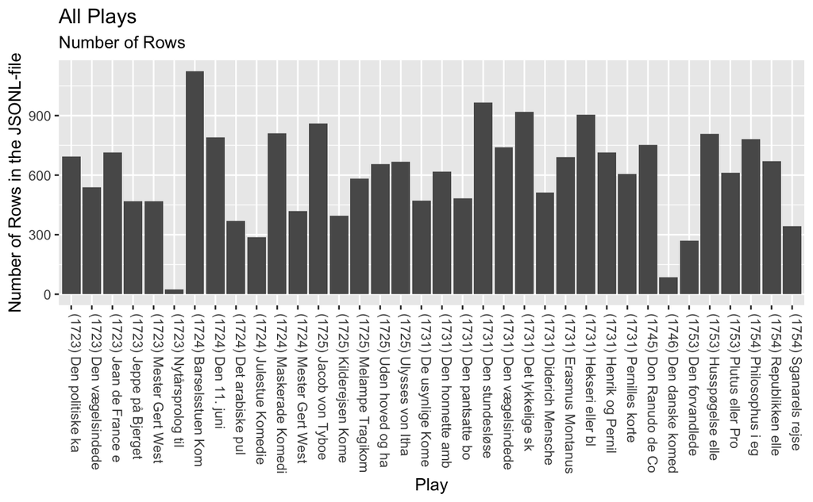

```
antal_replikker %>%
  ggplot(aes(y = replikker, x = str_c(year, " ", str_sub(docTitle,0,16)))) +
  theme(axis.text.x = element_text(angle = -90, hjust = 0, vjust = 0)) +
    geom_bar(stat="identity") +
    theme(legend.position="bottom") +
    labs(
      title = "All plays",
      subtitle = "Number of Character-lines"
    ) +
  xlab("Play") +
  ylab("Number of Character-lines in the Play")
ggsave(here("graphs/read-plays", "Optælling_af_replikker.pdf"))
```

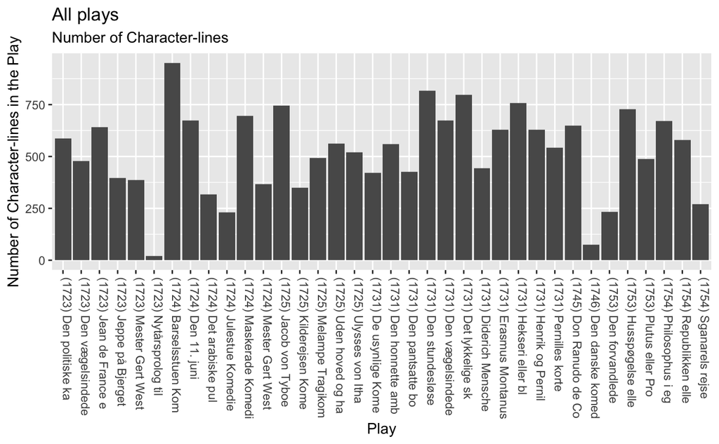

```
antal_ord %>%
  ggplot(aes(y = words, x = str_c(year, " ", str_sub(docTitle,0,16)))) +
  theme(axis.text.x = element_text(angle = -90, hjust = 0, vjust = 0)) +
    geom_bar(stat="identity") +
    theme(legend.position="bottom") +
    labs(
      title = "All Plays",
      subtitle = "Number of words"
    ) +
  xlab("Play") +
  ylab("Number of spoken words")

ggsave(here("graphs/read-plays", "Optælling_af_ord.pdf"))
```

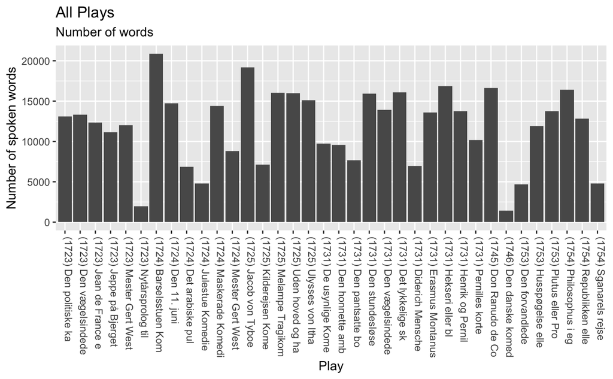

# Read in a single JSONL-file into R

Sometimes, the titles of plays are not as they should be, so we made a function to read in a single play. While the titles are now correct, it may still be helpful in some cases to read in a single play.

```
# This function retrieves the play inside the JSONL file that we call
read_play_jsonl(here(my_dir, "Den_Vaegelsindede_1731_mod.jsonl")) -> play
play # Call "play" to see the table that has now been assigned to that variable.
```

| filename | act | act_number | docTitle | index | scene | scene_number | speaker | speaker_stage | spoke | stage | title | type | year |
| --- | --- | --- | --- | --- | --- | --- | --- | --- | --- | --- | --- | --- | --- |
| Den_Vaegelsindede_1731_mod.jsonl | Første akt | 1 | Den vægelsindede Komedie i 3 akter | 1 | Scene 1 | 1 | NA | NA | NA | Helene, Leonore | Den vægelsindede | 1 | (1731) |
| Den_Vaegelsindede_1731_mod.jsonl | Første akt | 1 | Den vægelsindede Komedie i 3 akter | 2 | Scene 1 | 1 | Helene | NA | Tal aldrig derom, min kære jomfru, vi er lige vel faren begge, hvorvel vore opvartere er af stridige humeurs, så at jeg ved ikke hvo af os mest er at beklage. | NA | Den vægelsindede | 4 | (1731) |
| Den_Vaegelsindede_1731_mod.jsonl | Første akt | 1 | Den vægelsindede Komedie i 3 akter | 3 | Scene 1 | 1 | Leonore | NA | Det er uden tvivl jeg, thi enhver mandsperson der er dannet som hendes broder Eraste, kan fly et fruentimmer nok at bryde sit hoved med. Det lader som han elsker mig, men jeg kan forsikre hende at i a… | NA | Den vægelsindede | 4 | (1731) |
| Den_Vaegelsindede_1731_mod.jsonl | Første akt | 1 | Den vægelsindede Komedie i 3 akter | 4 | Scene 1 | 1 | Helene | NA | Hvad hendes broder Apicius angår, da kan jeg ikke sige at hans tale er forblommet. De allerprægtigste kærlighedserklæringer koster ham intet, men jeg ved ikke om jeg kan fæste mindste tro dertil, så u… | NA | Den vægelsindede | 4 | (1731) |
| Den_Vaegelsindede_1731_mod.jsonl | Første akt | 1 | Den vægelsindede Komedie i 3 akter | 5 | Scene 1 | 1 | Leonore | NA | Hun gør min tro vel deri, jomfru. Jeg skal min tro følge hendes eksempel. | NA | Den vægelsindede | 4 | (1731) |
| Den_Vaegelsindede_1731_mod.jsonl | Første akt | 1 | Den vægelsindede Komedie i 3 akter | 6 | Scene 1 | 1 | Helene | NA | Jeg tilstår vel at det er noget vanskeligt ganske at forlade den som man engang har gjort sig tanker om. | NA | Den vægelsindede | 4 | (1731) |
| Den_Vaegelsindede_1731_mod.jsonl | Første akt | 1 | Den vægelsindede Komedie i 3 akter | 7 | Scene 1 | 1 | Leonore | NA | Det er sandt nok. Men hvad er herved at gøre? | NA | Den vægelsindede | 4 | (1731) |
| Den_Vaegelsindede_1731_mod.jsonl | Første akt | 1 | Den vægelsindede Komedie i 3 akter | 8 | Scene 1 | 1 | Helene | NA | Jeg bilder mig ind at man nok skulle bringe dem på rette vej ved at forestille den ene hans alt for store ærbarhed og sparsommelighed, og at vise den anden hvor meget han lider formedelst hans flygtig… | NA | Den vægelsindede | 4 | (1731) |
| Den_Vaegelsindede_1731_mod.jsonl | Første akt | 1 | Den vægelsindede Komedie i 3 akter | 9 | Scene 1 | 1 | Leonore | NA | Ej, mon sådant ikke er sagt dem uden frugt hundrede gange tilforn? Jeg var tilfreds at monsieur Eraste var kendt med en vis dame som jeg talte med i går, som jeg ikke vil nævne. Jeg tror virkelig at d… | NA | Den vægelsindede | 4 | (1731) |
| Den_Vaegelsindede_1731_mod.jsonl | Første akt | 1 | Den vægelsindede Komedie i 3 akter | 10 | Scene 1 | 1 | Helene | NA | Hvor bor den dame? | NA | Den vægelsindede | 4 | (1731) |

[output cut: 731 more lines]

Now we count the number of lines, character-lines and stage directions of the single play, as we did above for all plays:

```
# Count the number of lines in the play
play %>% count(name = "# rækker")
```

| # rækker |
| --- |
| 741 |

```
# Count the number of character-lines
play %>%
  filter(!is.na(spoke)) %>% # Filter out the lines that are marked NA
  filter(!(spoke == "")) %>% # Filter out empty lines
  count(name = "# replikker")
```

| # replikker |
| --- |
| 673 |

```
# Count the number of lines of stage directions. Note that they can be found on two levels, preceeded in the JSON by <stage> or by <speaker_stage>. Let us count both the number of directions in each of these.
# Count the number of directions marked <stage>
play %>%
  filter(!is.na(stage)) %>% # Filter out the lines that are marked NA
  filter(!(stage == "")) %>% # Filter out empty lines
  count(name = "# stage")
```

| # stage |
| --- |
| 50 |

```
# Count the number of directions marked by <speaker_stage>
play %>%
  filter(!is.na(speaker_stage)) %>% # Filter out the lines that are marked NA
  filter(!(speaker_stage == "")) %>% # Filter out empty lines
  count(name = "# speaker_stage")
```

| # speaker_stage |
| --- |
| 26 |